# Predicting the World Cup Winner using Machine Learning

Millions of people across the world tune in to witness the FIFA World Cup, the most renowned and popular athletic event in the world. As the tournament draws near, excitement and expectation increase as fans, experts, and even casual observers speculate on the likely results and try to pick the final champion. There have been a lot of conversations, arguments, and predictions about who will win the World Cup based on a variety of variables, including team performance, player statistics, historical data, and even gut emotions.

This project's main aim is to investigate the possibilities of machine learning in the field of sports prediction, with a focus on the FIFA World Cup. By creating a strong prediction model, we intend to add to the body of knowledge and offer insightful information about the elements that affect the tournament's result.

Overall, this project aims to give a useful and cutting-edge method of forecasting the results of the tournament by fusing the thrill of the FIFA World Cup with the power of machine learning. By making a contribution to the field of sports analytics and prediction, we want to improve fan, stakeholder, and the larger sporting community comprehension of the game and produce insights.

```python
import pandas as pd
import seaborn as sns
import matplotlib.pyplot as plt
import numpy as np
```

```python
wc_data =  pd.read_csv("international_results.csv")
wc_data["date"] = pd.to_datetime(wc_data["date"])
wc_data = wc_data[(wc_data["date"] >= "2018-9-1")].reset_index(drop=True) # So after 2018 September

wc_rank = pd.read_csv("fifa_ranking.csv") #rankings
wc_rank["rank_date"] = pd.to_datetime(wc_rank["rank_date"])
wc_rank = wc_rank[(wc_rank["rank_date"] >= "2018-9-1")].reset_index(drop=True) # So after 2018 September

wc_rank["country_full"] = wc_rank["country_full"].str.replace("Korea Republic", "South Korea") # Change korea name
wc_rank["country_full"] = wc_rank["country_full"].str.replace("IR Iran", "Iran") # Change Iran name
wc_rank["country_full"] = wc_rank["country_full"].str.replace("USA", "United States") # Change USA name
wc_rank = wc_rank.set_index(['rank_date']).groupby(['country_full'], group_keys=False).resample('D').first().fillna(method='ffill').reset_index()

# Now merge everything
wc_final = wc_data.merge(wc_rank[["country_full", "total_points", "previous_points", "rank", "rank_change", "rank_date"]], left_on=["date", "home_team"], right_on=["rank_date", "country_full"]).drop(["rank_date", "country_full"], axis=1)
wc_final = wc_final.merge(wc_rank[["country_full", "total_points", "previous_points", "rank", "rank_change", "rank_date"]], left_on=["date", "away_team"], right_on=["rank_date", "country_full"], suffixes=("_home", "_away")).drop(["rank_date", "country_full"], axis=1)
```

We import our data from kaggle and we use two data set FIFA World Ranking and International football results.

So in the prepration we were only interested data from 2018 to 2022 so we did that and also needed to change some name because of the different name for same country in different dataset.

# Data Collection

# Processing Data

```python
wc_data.head()
```

|  | date | home_team | away_team | home_score | away_score | tournament | city | country | neutral |
| --- | --- | --- | --- | --- | --- | --- | --- | --- | --- |
| 0 | 2018-09-01 | Timor-Leste | Brunei | 3 | 1 | AFF Championship qualification | Kuala Lumpur | Malaysia | True |
| 1 | 2018-09-02 | Ethiopia | Burundi | 1 | 1 | Friendly | Hawassa | Ethiopia | False |
| 2 | 2018-09-02 | Guam | Northern Mariana Islands | 4 | 0 | EAFF Championship | Ulaanbaatar | Mongolia | True |
| 3 | 2018-09-02 | Mongolia | Macau | 4 | 1 | EAFF Championship | Ulaanbaatar | Mongolia | False |
| 4 | 2018-09-04 | Macau | Guam | 2 | 0 | EAFF Championship | Ulaanbaatar | Mongolia | True |

```python
wc_rank
```

|  | rank_date | rank | country_full | country_abrv | total_points | previous_points | rank_change | confederation |
| --- | --- | --- | --- | --- | --- | --- | --- | --- |
| 0 | 2018-09-20 | 146.0 | Afghanistan | AFG | 1068.00 | 1068.00 | 1.0 | AFC |
| 1 | 2018-09-21 | 146.0 | Afghanistan | AFG | 1068.00 | 1068.00 | 1.0 | AFC |
| 2 | 2018-09-22 | 146.0 | Afghanistan | AFG | 1068.00 | 1068.00 | 1.0 | AFC |
| 3 | 2018-09-23 | 146.0 | Afghanistan | AFG | 1068.00 | 1068.00 | 1.0 | AFC |
| 4 | 2018-09-24 | 146.0 | Afghanistan | AFG | 1068.00 | 1068.00 | 1.0 | AFC |
| ... | ... | ... | ... | ... | ... | ... | ... | ... |
| 330680 | 2022-12-18 | 125.0 | Zimbabwe | ZIM | 1138.56 | 1138.56 | 2.0 | CAF |
| 330681 | 2022-12-19 | 125.0 | Zimbabwe | ZIM | 1138.56 | 1138.56 | 2.0 | CAF |
| 330682 | 2022-12-20 | 125.0 | Zimbabwe | ZIM | 1138.56 | 1138.56 | 2.0 | CAF |
| 330683 | 2022-12-21 | 125.0 | Zimbabwe | ZIM | 1138.56 | 1138.56 | 2.0 | CAF |
| 330684 | 2022-12-22 | 125.0 | Zimbabwe | ZIM | 1138.56 | 1138.56 | 0.0 | CAF |

330685 rows × 8 columns

The concept behind feature engineering is to identify potential factors that can significantly influence the prediction of football games. Based on intuition, we believe the following features could have an impact:

Previous game points earned Goals scored and conceded in previous matches The significance of the game (friendly or competitive) Team rankings Changes in team rankings over time Goals scored and conceded against teams with different rankings

```python
wc_final
```

|  | date | home_team | away_team | home_score | away_score | tournament | city | country | neutral | total_points_home | previous_points_home | rank_home | rank_change_home | total_points_away | previous_points_away | rank_away | rank_change_away |
| --- | --- | --- | --- | --- | --- | --- | --- | --- | --- | --- | --- | --- | --- | --- | --- | --- | --- |
| 0 | 2018-09-30 | Botswana | Namibia | 1 | 0 | Friendly | Gaborone | Botswana | False | 1077.00 | 1089.00 | 142.0 | 3.0 | 1170.00 | 1166.00 | 116.0 | -1.0 |
| 1 | 2018-10-10 | Albania | Jordan | 0 | 0 | Friendly | Elbasan | Albania | False | 1383.00 | 1384.00 | 57.0 | -1.0 | 1189.00 | 1192.00 | 110.0 | 0.0 |
| 2 | 2018-10-10 | Indonesia | Myanmar | 3 | 0 | Friendly | Cikarang | Indonesia | False | 997.00 | 992.00 | 164.0 | 0.0 | 1092.00 | 1092.00 | 138.0 | 0.0 |
| 3 | 2018-10-10 | Italy | Ukraine | 1 | 1 | Friendly | Genoa | Italy | False | 1526.00 | 1532.00 | 20.0 | -1.0 | 1483.00 | 1468.00 | 29.0 | -6.0 |
| 4 | 2018-10-10 | Ethiopia | Kenya | 0 | 0 | African Cup of Nations qualification | Bahir Dar | Ethiopia | False | 1060.00 | 1044.00 | 149.0 | -2.0 | 1204.00 | 1182.00 | 107.0 | -5.0 |
| ... | ... | ... | ... | ... | ... | ... | ... | ... | ... | ... | ... | ... | ... | ... | ... | ... | ... |
| 3360 | 2022-12-14 | Malaysia | Maldives | 3 | 0 | Friendly | Kuala Lumpur | Malaysia | False | 1062.32 | 1057.59 | 146.0 | -2.0 | 1026.09 | 1018.25 | 154.0 | -2.0 |
| 3361 | 2022-12-14 | Vietnam | Philippines | 1 | 0 | Friendly | Hanoi | Vietnam | False | 1226.65 | 1218.84 | 96.0 | -1.0 | 1115.13 | 1115.13 | 133.0 | -1.0 |
| 3362 | 2022-12-17 | Croatia | Morocco | 2 | 1 | FIFA World Cup | Al Rayyan | Qatar | True | 1645.64 | 1632.15 | 12.0 | -3.0 | 1563.50 | 1558.35 | 22.0 | -1.0 |
| 3363 | 2022-12-17 | Singapore | Maldives | 3 | 1 | Friendly | Singapore | Singapore | False | 1003.50 | 1004.75 | 160.0 | 1.0 | 1026.09 | 1018.25 | 154.0 | -2.0 |
| 3364 | 2022-12-18 | Argentina | France | 3 | 3 | FIFA World Cup | Lusail | Qatar | True | 1773.88 | 1770.65 | 3.0 | 0.0 | 1759.78 | 1764.85 | 4.0 | 0.0 |

3365 rows × 17 columns

To begin, we should create a feature that indicates which team won and the number of points they obtained in a game.

Possible features - all for last 5 games:

Wins by Ranking, Defeats by Ranking, rank diff, Rank Change, is friendly, Goals scored by ranking, Goals conceded by ranking, Rank difference faced,

```python
def find_result(home, away):
    if home > away:
        return pd.Series([0, 3, 0])
    if home < away:
        return pd.Series([1, 0, 3])
    else:
        return pd.Series([2, 1, 1])

results = wc_final.apply(lambda x: find_result(x["home_score"], x["away_score"]), axis=1)
```

```python
wc_final[["result", "home_team_points", "away_team_points"]] = results
```

```python
wc_final.columns
```

```
Index(['date', 'home_team', 'away_team', 'home_score', 'away_score',
       'tournament', 'city', 'country', 'neutral', 'total_points_home',
       'previous_points_home', 'rank_home', 'rank_change_home',
       'total_points_away', 'previous_points_away', 'rank_away',
       'rank_change_away', 'result', 'home_team_points', 'away_team_points'],
      dtype='object')
```

In here we can make an assumption that the rank is negatively correlated with total points, so we use heatmap to prove this

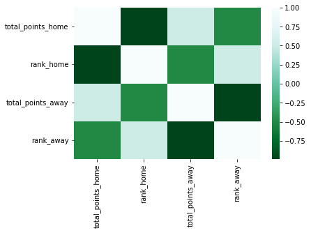

[output not shown]

[output cut: 377 more lines]

[output not shown]

```python
import seaborn as sns

sns.heatmap(wc_final[["total_points_home", "rank_home", "total_points_away", "rank_away"]].corr(), cmap="BuGn_r")
```

Next, we generate columns that will facilitate the creation of the features. These columns include the difference in rankings, points earned in the game compared to the rank of the opposing team, and the difference in goals scored during the game. It is important to create these features separately for both the home and away teams, ensuring that features other than differences are accounted for.

```python
wc_final["rank_dif"] = wc_final["rank_home"] - wc_final["rank_away"]
wc_final["sg"] = wc_final["home_score"] - wc_final["away_score"]
wc_final["points_home_by_rank"] = wc_final["home_team_points"]/wc_final["rank_away"]
wc_final["points_away_by_rank"] = wc_final["away_team_points"]/wc_final["rank_home"]
```

Possibilities:

- Average rank and average rank difference (test for full and test for 5 games, analyze the best)
- Goals scored by ranking of the teams faced (and the difference)
- Goals conceded by ranking of the teams faced (and the difference)

```python
wc_final
```

|  | date | home_team | away_team | home_score | away_score | tournament | city | country | neutral | total_points_home | ... | previous_points_away | rank_away | rank_change_away | result | home_team_points | away_team_points | rank_dif | sg | points_home_by_rank | points_away_by_rank |
| --- | --- | --- | --- | --- | --- | --- | --- | --- | --- | --- | --- | --- | --- | --- | --- | --- | --- | --- | --- | --- | --- |
| 0 | 2018-09-30 | Botswana | Namibia | 1 | 0 | Friendly | Gaborone | Botswana | False | 1077.00 | ... | 1166.00 | 116.0 | -1.0 | 0 | 3 | 0 | 26.0 | 1 | 0.025862 | 0.000000 |
| 1 | 2018-10-10 | Albania | Jordan | 0 | 0 | Friendly | Elbasan | Albania | False | 1383.00 | ... | 1192.00 | 110.0 | 0.0 | 2 | 1 | 1 | -53.0 | 0 | 0.009091 | 0.017544 |
| 2 | 2018-10-10 | Indonesia | Myanmar | 3 | 0 | Friendly | Cikarang | Indonesia | False | 997.00 | ... | 1092.00 | 138.0 | 0.0 | 0 | 3 | 0 | 26.0 | 3 | 0.021739 | 0.000000 |
| 3 | 2018-10-10 | Italy | Ukraine | 1 | 1 | Friendly | Genoa | Italy | False | 1526.00 | ... | 1468.00 | 29.0 | -6.0 | 2 | 1 | 1 | -9.0 | 0 | 0.034483 | 0.050000 |
| 4 | 2018-10-10 | Ethiopia | Kenya | 0 | 0 | African Cup of Nations qualification | Bahir Dar | Ethiopia | False | 1060.00 | ... | 1182.00 | 107.0 | -5.0 | 2 | 1 | 1 | 42.0 | 0 | 0.009346 | 0.006711 |
| ... | ... | ... | ... | ... | ... | ... | ... | ... | ... | ... | ... | ... | ... | ... | ... | ... | ... | ... | ... | ... | ... |
| 3360 | 2022-12-14 | Malaysia | Maldives | 3 | 0 | Friendly | Kuala Lumpur | Malaysia | False | 1062.32 | ... | 1018.25 | 154.0 | -2.0 | 0 | 3 | 0 | -8.0 | 3 | 0.019481 | 0.000000 |
| 3361 | 2022-12-14 | Vietnam | Philippines | 1 | 0 | Friendly | Hanoi | Vietnam | False | 1226.65 | ... | 1115.13 | 133.0 | -1.0 | 0 | 3 | 0 | -37.0 | 1 | 0.022556 | 0.000000 |
| 3362 | 2022-12-17 | Croatia | Morocco | 2 | 1 | FIFA World Cup | Al Rayyan | Qatar | True | 1645.64 | ... | 1558.35 | 22.0 | -1.0 | 0 | 3 | 0 | -10.0 | 1 | 0.136364 | 0.000000 |
| 3363 | 2022-12-17 | Singapore | Maldives | 3 | 1 | Friendly | Singapore | Singapore | False | 1003.50 | ... | 1018.25 | 154.0 | -2.0 | 0 | 3 | 0 | 6.0 | 2 | 0.019481 | 0.000000 |
| 3364 | 2022-12-18 | Argentina | France | 3 | 3 | FIFA World Cup | Lusail | Qatar | True | 1773.88 | ... | 1764.85 | 4.0 | 0.0 | 2 | 1 | 1 | -1.0 | 0 | 0.250000 | 0.333333 |

3365 rows × 24 columns

```python
wc_final.columns
```

```
Index(['date', 'home_team', 'away_team', 'home_score', 'away_score',
       'tournament', 'city', 'country', 'neutral', 'total_points_home',
       'previous_points_home', 'rank_home', 'rank_change_home',
       'total_points_away', 'previous_points_away', 'rank_away',
       'rank_change_away', 'result', 'home_team_points', 'away_team_points',
       'rank_dif', 'sg', 'points_home_by_rank', 'points_away_by_rank'],
      dtype='object')
```

To create the features, I will divide the dataset into two separate parts: one for the home team and another for the away team. I will then combine these two datasets and calculate the values based on past games. Following this, I will once again separate and merge the datasets, thereby restoring the original dataset. This process enhances the efficiency of feature creation.

```python
home_team = wc_final[["date", "home_team", "home_score", "away_score", "rank_home", "rank_away","rank_change_home", "total_points_home", "result", "rank_dif", "points_home_by_rank", "home_team_points"]]

away_team = wc_final[["date", "away_team", "away_score", "home_score", "rank_away", "rank_home","rank_change_away", "total_points_away", "result", "rank_dif", "points_away_by_rank", "away_team_points"]]

home_team.columns = [h.replace("home_", "").replace("_home", "").replace("away_", "suf_").replace("_away", "_suf") for h in home_team.columns]

away_team.columns = [a.replace("away_", "").replace("_away", "").replace("home_", "suf_").replace("_home", "_suf") for a in away_team.columns]

team_stats = home_team.append(away_team)

team_stats
```

|  | date | team | score | suf_score | rank | rank_suf | rank_change | total_points | result | rank_dif | points_by_rank | team_points |
| --- | --- | --- | --- | --- | --- | --- | --- | --- | --- | --- | --- | --- |
| 0 | 2018-09-30 | Botswana | 1 | 0 | 142.0 | 116.0 | 3.0 | 1077.00 | 0 | 26.0 | 0.025862 | 3 |
| 1 | 2018-10-10 | Albania | 0 | 0 | 57.0 | 110.0 | -1.0 | 1383.00 | 2 | -53.0 | 0.009091 | 1 |
| 2 | 2018-10-10 | Indonesia | 3 | 0 | 164.0 | 138.0 | 0.0 | 997.00 | 0 | 26.0 | 0.021739 | 3 |
| 3 | 2018-10-10 | Italy | 1 | 1 | 20.0 | 29.0 | -1.0 | 1526.00 | 2 | -9.0 | 0.034483 | 1 |
| 4 | 2018-10-10 | Ethiopia | 0 | 0 | 149.0 | 107.0 | -2.0 | 1060.00 | 2 | 42.0 | 0.009346 | 1 |
| ... | ... | ... | ... | ... | ... | ... | ... | ... | ... | ... | ... | ... |
| 3360 | 2022-12-14 | Maldives | 0 | 3 | 154.0 | 146.0 | -2.0 | 1026.09 | 0 | -8.0 | 0.000000 | 0 |
| 3361 | 2022-12-14 | Philippines | 0 | 1 | 133.0 | 96.0 | -1.0 | 1115.13 | 0 | -37.0 | 0.000000 | 0 |
| 3362 | 2022-12-17 | Morocco | 1 | 2 | 22.0 | 12.0 | -1.0 | 1563.50 | 0 | -10.0 | 0.000000 | 0 |
| 3363 | 2022-12-17 | Maldives | 1 | 3 | 154.0 | 160.0 | -2.0 | 1026.09 | 0 | 6.0 | 0.000000 | 0 |
| 3364 | 2022-12-18 | France | 3 | 3 | 4.0 | 3.0 | 0.0 | 1759.78 | 2 | -1.0 | 0.333333 | 1 |

6730 rows × 12 columns

We now have a prepared database for creating predictive features. These features will include:

1. Average number of goals scored by the team in the World Cup Cycle.
2. Average number of goals scored by the team in the last five games.
3. Average number of goals conceded by the team in the World Cup Cycle.
4. Average number of goals conceded by the team in the last five games.
5. Average FIFA rank of the teams faced by the team in the World Cup Cycle.
6. Average FIFA rank of the teams faced by the team in the last five games.
7. Total FIFA points earned during the cycle.
8. Total FIFA points earned in the last five games.
9. Average points earned per game in the World Cup Cycle.
10. Average points earned per game in the last five games.
11. Average points earned per game based on the rank of the teams faced in the World Cup Cycle.
12. Average points earned per game based on the rank of the teams faced in the last five games.

```python
team_stats.columns
```

```
Index(['date', 'team', 'score', 'suf_score', 'rank', 'rank_suf', 'rank_change',
       'total_points', 'result', 'rank_dif', 'points_by_rank', 'team_points'],
      dtype='object')
```

```python
stats_val = []

for index, row in team_stats.iterrows():
    team = row["team"]
    date = row["date"]
    past_games = team_stats.loc[(team_stats["team"] == team) & (team_stats["date"] < date)].sort_values(by=['date'], ascending=False)
    last_5 = past_games.head(5)

    goals = past_games["score"].mean()
    goals_l5 = last_5["score"].mean()

    goals_suf = past_games["suf_score"].mean()
    goals_suf_l5 = last_5["suf_score"].mean()

    rank = past_games["rank_suf"].mean()
    rank_l5 = last_5["rank_suf"].mean()

    if len(last_5) > 0:
        points = past_games["total_points"].values[0] - past_games["total_points"].values[-1]
        points_l5 = last_5["total_points"].values[0] - last_5["total_points"].values[-1]
    else:
        points = 0
        points_l5 = 0

    gp = past_games["team_points"].mean()
    gp_l5 = last_5["team_points"].mean()

    gp_rank = past_games["points_by_rank"].mean()
    gp_rank_l5 = last_5["points_by_rank"].mean()

    stats_val.append([goals, goals_l5, goals_suf, goals_suf_l5, rank, rank_l5, points, points_l5, gp, gp_l5, gp_rank, gp_rank_l5])
```

```python
stats_val[-1]
```

```
[2.1153846153846154,
 1.8,
 0.8269230769230769,
 0.8,
 41.88461538461539,
 18.6,
 30.779999999999973,
 0.0,
 2.173076923076923,
 2.4,
 0.17734371301809745,
 0.23034965034965035]
```

```python
stats_mean = ["goals_mean", "goals_mean_l5", "goals_suf_mean", "goals_suf_mean_l5", "rank_mean", "rank_mean_l5", "points_mean", "points_mean_l5", "game_points_mean", "game_points_mean_l5", "game_points_rank_mean", "game_points_rank_mean_l5"]
```

```python
stats_df = pd.DataFrame(stats_val, columns=stats_mean)

full_df = pd.concat([team_stats.reset_index(drop=True), stats_df], axis=1, ignore_index=False)


home_team_stats = full_df.iloc[:int(full_df.shape[0]/2),:]
away_team_stats = full_df.iloc[int(full_df.shape[0]/2):,:]
```

```python
home_team_stats.columns[-12:]
```

```
Index(['goals_mean', 'goals_mean_l5', 'goals_suf_mean', 'goals_suf_mean_l5',
       'rank_mean', 'rank_mean_l5', 'points_mean', 'points_mean_l5',
       'game_points_mean', 'game_points_mean_l5', 'game_points_rank_mean',
       'game_points_rank_mean_l5'],
      dtype='object')
```

```python
home_team_stats = home_team_stats[home_team_stats.columns[-12:]]
away_team_stats = away_team_stats[away_team_stats.columns[-12:]]

home_team_stats.columns = ['home_'+str(col) for col in home_team_stats.columns]
away_team_stats.columns = ['away_'+str(col) for col in away_team_stats.columns]

match_stats = pd.concat([home_team_stats, away_team_stats.reset_index(drop=True)], axis=1, ignore_index=False)

final_df = pd.concat([wc_final, match_stats.reset_index(drop=True)], axis=1, ignore_index=False)

final_df.columns
```

```
Index(['date', 'home_team', 'away_team', 'home_score', 'away_score',
       'tournament', 'city', 'country', 'neutral', 'total_points_home',
       'previous_points_home', 'rank_home', 'rank_change_home',
       'total_points_away', 'previous_points_away', 'rank_away',
       'rank_change_away', 'result', 'home_team_points', 'away_team_points',
       'rank_dif', 'sg', 'points_home_by_rank', 'points_away_by_rank',
       'home_goals_mean', 'home_goals_mean_l5', 'home_goals_suf_mean',
       'home_goals_suf_mean_l5', 'home_rank_mean', 'home_rank_mean_l5',
       'home_points_mean', 'home_points_mean_l5', 'home_game_points_mean',
       'home_game_points_mean_l5', 'home_game_points_rank_mean',
       'home_game_points_rank_mean_l5', 'away_goals_mean',
       'away_goals_mean_l5', 'away_goals_suf_mean', 'away_goals_suf_mean_l5',
       'away_rank_mean', 'away_rank_mean_l5', 'away_points_mean',
       'away_points_mean_l5', 'away_game_points_mean',
       'away_game_points_mean_l5', 'away_game_points_rank_mean',
       'away_game_points_rank_mean_l5'],
      dtype='object')
```

To consolidate the database, it is necessary to append a suffix indicating "home" or "away" to each column. Once this is done, the data is prepared for merging.

Now to quantify the significance of each game, a new column is generated that identifies the type of competition for that particular match.

```python
def friendly_game(x):
    if x == "Friendly":
        return 1
    else: return 0

final_df["is_friendly"] = final_df["tournament"].apply(lambda x: friendly_game(x))
```

```python
final_df = pd.get_dummies(final_df, columns=["is_friendly"])

final_df.columns
```

```
Index(['date', 'home_team', 'away_team', 'home_score', 'away_score',
       'tournament', 'city', 'country', 'neutral', 'total_points_home',
       'previous_points_home', 'rank_home', 'rank_change_home',
       'total_points_away', 'previous_points_away', 'rank_away',
       'rank_change_away', 'result', 'home_team_points', 'away_team_points',
       'rank_dif', 'sg', 'points_home_by_rank', 'points_away_by_rank',
       'home_goals_mean', 'home_goals_mean_l5', 'home_goals_suf_mean',
       'home_goals_suf_mean_l5', 'home_rank_mean', 'home_rank_mean_l5',
       'home_points_mean', 'home_points_mean_l5', 'home_game_points_mean',
       'home_game_points_mean_l5', 'home_game_points_rank_mean',
       'home_game_points_rank_mean_l5', 'away_goals_mean',
       'away_goals_mean_l5', 'away_goals_suf_mean', 'away_goals_suf_mean_l5',
       'away_rank_mean', 'away_rank_mean_l5', 'away_points_mean',
       'away_points_mean_l5', 'away_game_points_mean',
       'away_game_points_mean_l5', 'away_game_points_rank_mean',
       'away_game_points_rank_mean_l5', 'is_friendly_0', 'is_friendly_1'],
      dtype='object')
```

Following that, we proceed to select only the columns that are relevant for the analysis of the features.

```python
the_df = final_df[["date", "home_team", "away_team", "rank_home", "rank_away","home_score", "away_score","result", "rank_dif", "rank_change_home", "rank_change_away", 'home_goals_mean',
       'home_goals_mean_l5', 'home_goals_suf_mean', 'home_goals_suf_mean_l5',
       'home_rank_mean', 'home_rank_mean_l5', 'home_points_mean',
       'home_points_mean_l5', 'away_goals_mean', 'away_goals_mean_l5',
       'away_goals_suf_mean', 'away_goals_suf_mean_l5', 'away_rank_mean',
       'away_rank_mean_l5', 'away_points_mean', 'away_points_mean_l5','home_game_points_mean', 'home_game_points_mean_l5',
       'home_game_points_rank_mean', 'home_game_points_rank_mean_l5','away_game_points_mean',
       'away_game_points_mean_l5', 'away_game_points_rank_mean',
       'away_game_points_rank_mean_l5',
       'is_friendly_0', 'is_friendly_1']]
```

```python
df = the_df.dropna()

df.result.value_counts()
```

```
0    1551
1     926
2     761
Name: result, dtype: int64
```

Games with missing values (represented as "NA") indicate that the corresponding metrics could not be calculated, particularly for the games at the beginning of the dataset. We will exclude these games from further analysis by removing them from the dataset.df

```python
df
```

|  | date | home_team | away_team | rank_home | rank_away | home_score | away_score | result | rank_dif | rank_change_home | ... | home_game_points_mean | home_game_points_mean_l5 | home_game_points_rank_mean | home_game_points_rank_mean_l5 | away_game_points_mean | away_game_points_mean_l5 | away_game_points_rank_mean | away_game_points_rank_mean_l5 | is_friendly_0 | is_friendly_1 |
| --- | --- | --- | --- | --- | --- | --- | --- | --- | --- | --- | --- | --- | --- | --- | --- | --- | --- | --- | --- | --- | --- |
| 62 | 2018-10-14 | Poland | Italy | 18.0 | 20.0 | 0 | 1 | 1 | -2.0 | 0.0 | ... | 0.000000 | 0.0 | 0.000000 | 0.000000 | 1.000000 | 1.0 | 0.034483 | 0.034483 | 1 | 0 |
| 63 | 2018-10-14 | Russia | Turkey | 46.0 | 38.0 | 2 | 0 | 0 | 8.0 | -3.0 | ... | 1.000000 | 1.0 | 0.066667 | 0.066667 | 1.000000 | 1.0 | 0.029412 | 0.029412 | 1 | 0 |
| 64 | 2018-10-14 | Israel | Albania | 94.0 | 57.0 | 2 | 0 | 0 | 37.0 | 1.0 | ... | 3.000000 | 3.0 | 0.076923 | 0.076923 | 1.000000 | 1.0 | 0.009091 | 0.009091 | 1 | 0 |
| 65 | 2018-10-14 | Romania | Serbia | 27.0 | 35.0 | 0 | 0 | 2 | -8.0 | -1.0 | ... | 3.000000 | 3.0 | 0.023810 | 0.023810 | 3.000000 | 3.0 | 0.073171 | 0.073171 | 1 | 0 |
| 66 | 2018-10-14 | Lithuania | Montenegro | 126.0 | 41.0 | 1 | 4 | 1 | 85.0 | -1.0 | ... | 0.000000 | 0.0 | 0.000000 | 0.000000 | 0.000000 | 0.0 | 0.000000 | 0.000000 | 1 | 0 |
| ... | ... | ... | ... | ... | ... | ... | ... | ... | ... | ... | ... | ... | ... | ... | ... | ... | ... | ... | ... | ... | ... |
| 3360 | 2022-12-14 | Malaysia | Maldives | 146.0 | 154.0 | 3 | 0 | 0 | -8.0 | -2.0 | ... | 1.756757 | 1.6 | 0.011816 | 0.010218 | 1.227273 | 1.8 | 0.006476 | 0.009363 | 0 | 1 |
| 3361 | 2022-12-14 | Vietnam | Philippines | 96.0 | 133.0 | 1 | 0 | 0 | -37.0 | -1.0 | ... | 1.611111 | 2.0 | 0.013659 | 0.022238 | 1.000000 | 0.8 | 0.006437 | 0.004550 | 0 | 1 |
| 3362 | 2022-12-17 | Croatia | Morocco | 12.0 | 22.0 | 2 | 1 | 0 | -10.0 | -3.0 | ... | 1.679245 | 1.2 | 0.107306 | 0.322967 | 2.104167 | 2.0 | 0.074431 | 0.409872 | 1 | 0 |
| 3363 | 2022-12-17 | Singapore | Maldives | 160.0 | 154.0 | 3 | 1 | 0 | 6.0 | 1.0 | ... | 1.333333 | 1.0 | 0.009430 | 0.007240 | 1.173913 | 1.8 | 0.006195 | 0.009363 | 0 | 1 |
| 3364 | 2022-12-18 | Argentina | France | 3.0 | 4.0 | 3 | 3 | 2 | -1.0 | 0.0 | ... | 2.240741 | 2.6 | 0.140007 | 0.160020 | 2.173077 | 2.4 | 0.177344 | 0.230350 | 1 | 0 |

3238 rows × 37 columns

Next, we will examine all the features that have been created and evaluate their predictive ability. If any of the features do not demonstrate sufficient predictive power, we will explore additional options, such as incorporating the differences between the home and away teams. To assess the predictive power, we will consider draw games as losses for the home team, effectively transforming the problem into a binary classification scenario

```python
def remove_draw(x):
    if x == 2:
        return 1
    else:
        return x

df["target"] = df["result"].apply(lambda x: remove_draw(x))
```

```python
model = df.drop(["result"], axis=1)
```

Now we want to graphically visualize and using this choose the appropriate features so we used violin plots to analysis the distribution and one with similarity feature and good distribution we will select

```python
data1 = df[list(df.columns[8:20].values) + ["target"]]
data2 = df[df.columns[20:]]
```

```python
scaled = (data1[:-1] - data1[:-1].mean()) / data1[:-1].std()
scaled["target"] = data1["target"]
violin1 = pd.melt(scaled,id_vars="target", var_name="features", value_name="value")
```

```python
scaled = (data2[:-1] - data2[:-1].mean()) / data2[:-1].std()
scaled["target"] = data2["target"]
violin2 = pd.melt(scaled,id_vars="target", var_name="features", value_name="value")
```

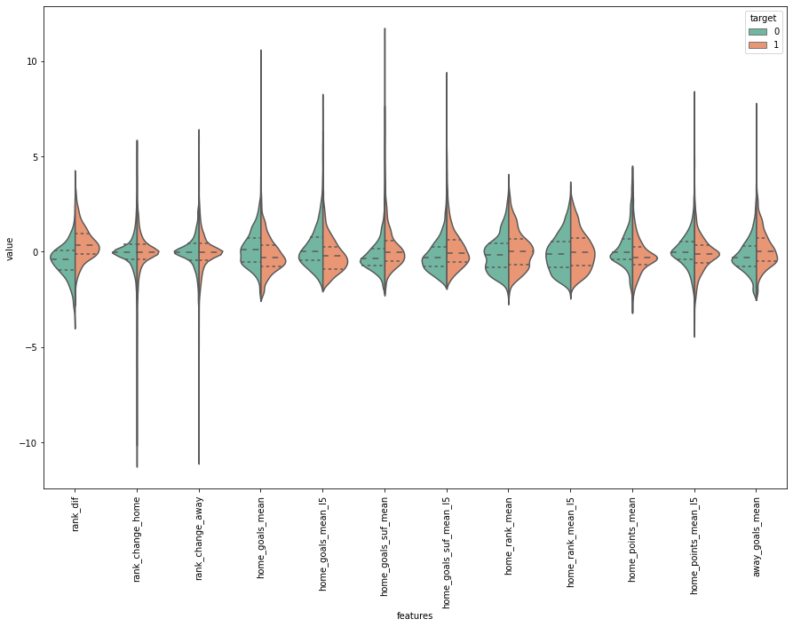

```python
plt.figure(figsize=(15,10))
sns.violinplot(x="features", y="value", hue="target", palette="Set2",data=violin1,split=True, inner="quart")
plt.xticks(rotation=90)
plt.show()
```

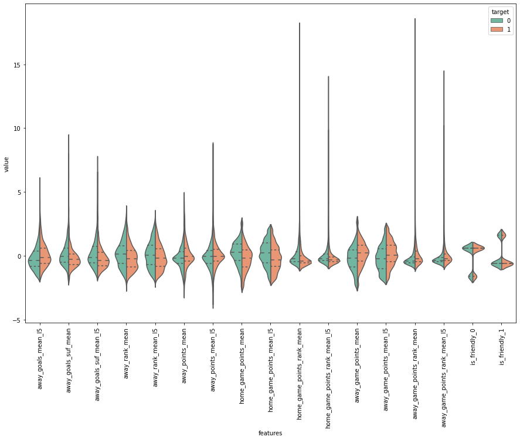

```python
plt.figure(figsize=(15,10))
sns.violinplot(x="features", y="value", hue="target", palette="Set2",data=violin2,split=True, inner="quart")
plt.xticks(rotation=90)
plt.show()
```

Based on the plotted data, we discover that the rank difference is the only feature that effectively separates the data. However, we can create additional features that capture the differences between the home and away teams and evaluate if they can also serve as effective separators in the data.

```python
diference = df.copy()
diference.loc[:, "goals_dif"] = diference["home_goals_mean"] - diference["away_goals_mean"]
diference.loc[:, "goals_dif_l5"] = diference["home_goals_mean_l5"] - diference["away_goals_mean_l5"]
diference.loc[:, "goals_suf_dif"] = diference["home_goals_suf_mean"] - diference["away_goals_suf_mean"]
diference.loc[:, "goals_suf_dif_l5"] = diference["home_goals_suf_mean_l5"] - diference["away_goals_suf_mean_l5"]
diference.loc[:, "goals_made_suf_dif"] = diference["home_goals_mean"] - diference["away_goals_suf_mean"]
diference.loc[:, "goals_made_suf_dif_l5"] = diference["home_goals_mean_l5"] - diference["away_goals_suf_mean_l5"]
diference.loc[:, "goals_suf_made_dif"] = diference["home_goals_suf_mean"] - diference["away_goals_mean"]
diference.loc[:, "goals_suf_made_dif_l5"] = diference["home_goals_suf_mean_l5"] - diference["away_goals_mean_l5"]
```

```python
data_diference = diference.iloc[:, -8:]
```

```python
scaled = (data_diference - data_diference.mean()) / data_diference.std()
scaled["target"] = data2["target"]
violin = pd.melt(scaled,id_vars="target", var_name="features", value_name="value")
```

[output not shown]

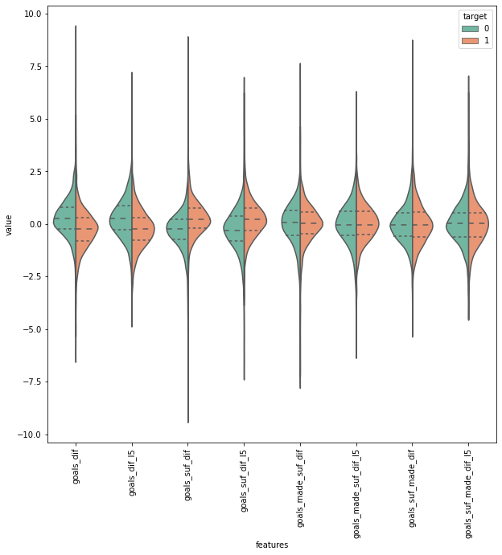

```python
plt.figure(figsize=(10,10))
sns.violinplot(x="features", y="value", hue="target", palette="Set2",data=violin,split=True, inner="quart")
plt.xticks(rotation=90)
```

Based on the plotted data, we observe that the goal difference and goals suffered difference are effective separators, whereas the difference between goals made and goals suffered of the teams is not a strong separator.

Currently, we have five features:

1. rank_dif (Rank difference)
2. goals_dif (Goal difference)
3. goals_dif_l5 (Goal difference in the last five games)
4. goals_suf_dif (Goals suffered difference)
5. goals_suf_dif_l5 (Goals suffered difference in the last five games)

To enhance our feature set, we can create additional features such as differences in points made, differences in points made by the rank faced, and differences in the rank faced.

So based on our priority we concluded that the most important feature we will be using for the dataset to train and use our machine learning algorithms are:

```python
def create_db(df):
    columns = ["home_team", "away_team", "target", "rank_dif", "home_goals_mean", "home_rank_mean", "away_goals_mean", "away_rank_mean", "home_rank_mean_l5", "away_rank_mean_l5", "home_goals_suf_mean", "away_goals_suf_mean", "home_goals_mean_l5", "away_goals_mean_l5", "home_goals_suf_mean_l5", "away_goals_suf_mean_l5", "home_game_points_rank_mean", "home_game_points_rank_mean_l5", "away_game_points_rank_mean", "away_game_points_rank_mean_l5","is_friendly_0", "is_friendly_1"]

    base = df.loc[:, columns]
    base.loc[:, "goals_dif"] = base["home_goals_mean"] - base["away_goals_mean"]
    base.loc[:, "goals_dif_l5"] = base["home_goals_mean_l5"] - base["away_goals_mean_l5"]
    base.loc[:, "goals_suf_dif"] = base["home_goals_suf_mean"] - base["away_goals_suf_mean"]
    base.loc[:, "goals_suf_dif_l5"] = base["home_goals_suf_mean_l5"] - base["away_goals_suf_mean_l5"]
    base.loc[:, "goals_per_ranking_dif"] = (base["home_goals_mean"] / base["home_rank_mean"]) - (base["away_goals_mean"] / base["away_rank_mean"])
    base.loc[:, "dif_rank_agst"] = base["home_rank_mean"] - base["away_rank_mean"]
    base.loc[:, "dif_rank_agst_l5"] = base["home_rank_mean_l5"] - base["away_rank_mean_l5"]
    base.loc[:, "dif_points_rank"] = base["home_game_points_rank_mean"] - base["away_game_points_rank_mean"]
    base.loc[:, "dif_points_rank_l5"] = base["home_game_points_rank_mean_l5"] - base["away_game_points_rank_mean_l5"]

    model_df = base[["home_team", "away_team", "target", "rank_dif", "goals_dif", "goals_dif_l5", "goals_suf_dif", "goals_suf_dif_l5", "goals_per_ranking_dif", "dif_rank_agst", "dif_rank_agst_l5", "dif_points_rank", "dif_points_rank_l5", "is_friendly_0", "is_friendly_1"]]
    return model_df
```

```python
model_db = create_db(df)
```

```python
X = model_db.iloc[:, 3:]
y = model_db[["target"]]
from sklearn.ensemble import RandomForestClassifier, GradientBoostingClassifier
from sklearn.model_selection import train_test_split, GridSearchCV
X_train, X_test, y_train, y_test = train_test_split(X, y, test_size= 0.2, random_state=1)

gb = GradientBoostingClassifier(random_state=5)

params = {"learning_rate": [0.01, 0.1, 0.5],
            "min_samples_split": [5, 10],
            "min_samples_leaf": [3, 5],
            "max_depth":[3,5,10],
            "max_features":["sqrt"],
            "n_estimators":[100, 200]
         }

gb_cv = GridSearchCV(gb, params, cv = 3, n_jobs = -1, verbose = 20)

gb_cv.fit(X_train, np.ravel(y_train))
```

```
Fitting 3 folds for each of 72 candidates, totalling 216 fits
```

```
GridSearchCV(cv=3, estimator=GradientBoostingClassifier(random_state=5),
             n_jobs=-1,
             param_grid={'learning_rate': [0.01, 0.1, 0.5],
                         'max_depth': [3, 5, 10], 'max_features': ['sqrt'],
                         'min_samples_leaf': [3, 5],
                         'min_samples_split': [5, 10],
                         'n_estimators': [100, 200]},
             verbose=20)
```

```python
gb_cv.best_estimator_
```

```
GradientBoostingClassifier(learning_rate=0.01, max_features='sqrt',
                           min_samples_leaf=3, min_samples_split=10,
                           n_estimators=200, random_state=5)
```

```python
gb = gb_cv.best_estimator_
```

```python
params_rf = {"max_depth": [20],
                "min_samples_split": [10],
                "max_leaf_nodes": [175],
                "min_samples_leaf": [5],
                "n_estimators": [250],
                 "max_features": ["sqrt"],
                }

rf = RandomForestClassifier(random_state=1)

rf_cv = GridSearchCV(rf, params_rf, cv = 3, n_jobs = -1, verbose = False)

rf_cv.fit(X_train.values, np.ravel(y_train))
```

```
GridSearchCV(cv=3, estimator=RandomForestClassifier(random_state=1), n_jobs=-1,
             param_grid={'max_depth': [20], 'max_features': ['sqrt'],
                         'max_leaf_nodes': [175], 'min_samples_leaf': [5],
                         'min_samples_split': [10], 'n_estimators': [250]},
             verbose=False)
```

```python
rf = rf_cv.best_estimator_
```

# Model

In order to employ one of the models in the simulation, we built two models—one using gradient boosting and the other using random forest—and compared them. We chose to employ decision tree-based models because, according to our study, they work better in soccer-related challenges.

```python
from sklearn.metrics import confusion_matrix, roc_curve, roc_auc_score


def analyze(model):
    # Set custom colors for the graphs
    color_test = 'blue'
    color_train = 'green'


    fpr, tpr, _ = roc_curve(y_test, model.predict_proba(X_test)[:, 1])  # test AUC
    plt.figure(figsize=(15, 8))
    plt.plot([0, 1], [0, 1], 'k--')
    plt.plot(fpr, tpr, color=color_test, label="test")


    fpr_train, tpr_train, _ = roc_curve(y_train, model.predict_proba(X_train)[:, 1])  # train AUC
    plt.plot(fpr_train, tpr_train, color=color_train, label="train")
    auc_test = roc_auc_score(y_test, model.predict_proba(X_test)[:, 1])

    auc_train = roc_auc_score(y_train, model.predict_proba(X_train)[:, 1])

    plt.legend()
    plt.title('AUC score is %.2f on test and %.2f on training' % (auc_test, auc_train))
    plt.xlabel('False Positive Rate')
    plt.ylabel('True Positive Rate')
    plt.grid(True)
    plt.show()

    plt.figure(figsize=(8, 6))
    plt.bar(['Test AUC', 'Train AUC'], [auc_test, auc_train], color=[color_test, color_train])
    plt.title('AUC Comparison')
    plt.xlabel('Dataset')
    plt.ylabel('AUC Score')
    plt.show()

    plt.figure(figsize=(9, 7))
    cm = confusion_matrix(y_test, model.predict(X_test))
    sns.heatmap(cm, annot=True, fmt="d", cmap="BuGn_r")
    plt.title('Confusion Matrix')
    plt.show()
```

# ROC Curve and AUC Score:

For the predictions made by the model on the test and training datasets, the function determines the ROC curve and AUC (Area Under the Curve) score. It computes the false positive rate (FPR) and true positive rate (TPR) for various probability thresholds using the roc_curve function from sklearn.metrics. The ROC curve is produced by using plt.plot to plot the FPR and TPR data. The curve displays how well the model is able to differentiate between positive and negative samples. The roc_auc_score function from sklearn.metrics is used to determine the AUC scores for the test and training datasets. The generated test and training curves' custom colors are used to illustrate the ROC curve and AUC values. For reference, our figure has a diagonal dotted line (k--) that represents a random classifier.

### Confusion Matrix Visualization:

The confusion matrix for the model's predictions on the test dataset is calculated using the function. The confusion_matrix function from sklearn.metrics is used to generate the confusion matrix. The true positive, true negative, false positive, and false negative values are shown on the resultant confusion matrix using sns.heatmap. With annot=True, the heatmap is annotated with the actual values, and fmt="d" formats the numbers as integers. The plot of the confusion matrix is shown. The analyze function generates ROC curve visualizations, computes AUC scores, and displays the confusion matrix to aid in assessing the effectiveness of a machine learning model. These assessment measures shed light on the model's classification and prediction capabilities.

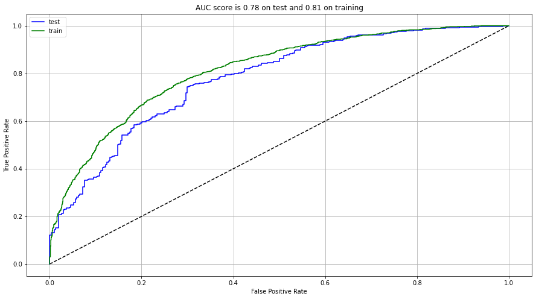

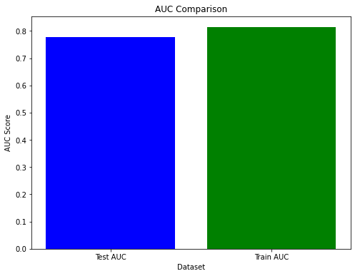

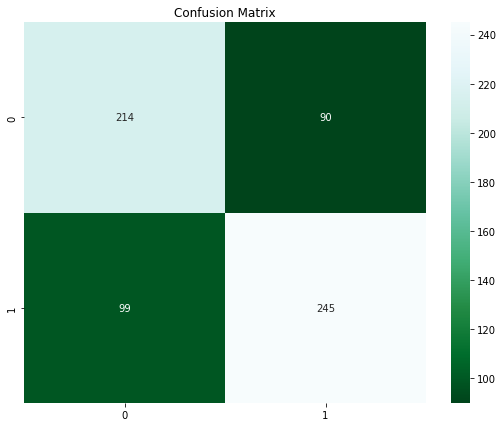

```python
analyze(gb)
```

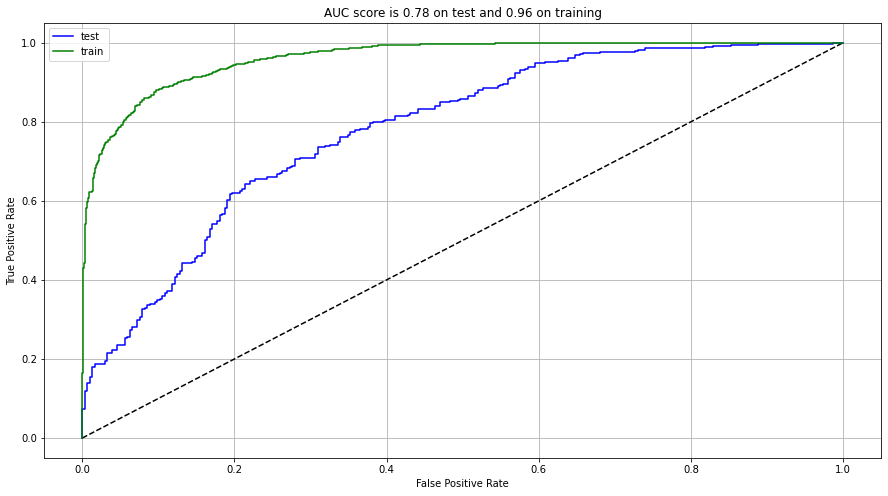

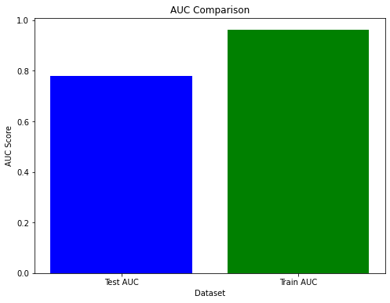

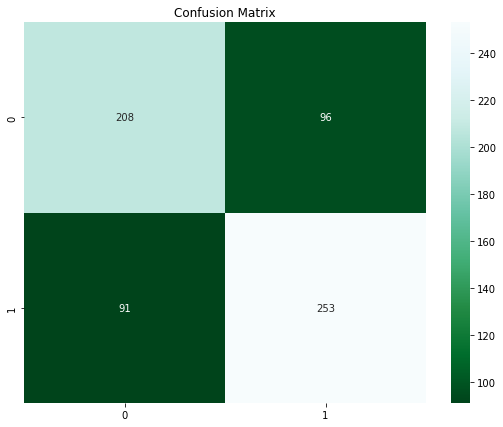

```python
analyze(rf)
```

# Reason for model selection

Although the Random Forest model performs marginally better, it appears to be overfit. Gradient Boosting's AUC-ROC analysis reveals a model with nearly the same performance but a smaller risk of overfitting, which is why it was chosen.